# Analysis of London spendings with python

In this post I want to discuss how you can use python to fetch data from the internet, put them in a readable format and gain some interesting insights.

This exercise is motivated by ["Using SQL for Lightweight Data Analysis"](http://schoolofdata.org/2013/03/26/using-sql-for-lightweight-data-analysis/) by Rufus Pollock. Here, I extend Rufus' analysis to a larger dataset and I use different analysis tools.

## The data

The data come from the ["London GLA spending"](https://www.london.gov.uk/about-us/greater-london-authority-gla/spending-money-wisely/our-spending) website, where GLA stands for Greater London Authority. Every month GLA publishes their spendings on Housing Services, Developing, Communities & Intelligence, etc. While writing, the GLA webpage contains 38 csv files with inhomogeneous formatting. There are empty columns and irregularly spaced data. To complicate things, the GLA website keeps changing root address and html design. So, I do not guarantee that the code described below will work in 2 years from now.

The webpage looks like this:

[figure not shown]

where we are interested in the content of the `CSV file` column.

The strategy is straightforward:

- scrap the html code of the GLA webpage;
- extract the links to the `.csv` files;
- download all the data and append the results to a `pandas` dataframe;
- Clean the data
- Have some fun with the data

# The code

We need some standard libraries like numpy and matplotlib, plus some less standard libraries with `BeautifulSoup` being the most important, because it allows to manipulate the html code hiding behind web pages. If you do not have `BeautifulSoup` installed, you can get it via `pip install BeautifulSoup`.

```python
import pandas as pd
from bs4 import BeautifulSoup
import urllib2
import matplotlib.pylab as plt
import re
import numpy as np
from __future__ import print_function
%matplotlib inline
```

The `html` code from the GLA webpage can be extracted with:

```python
wpage= 'https://www.london.gov.uk/about-us/greater-london-authority-gla/spending-money-wisely/our-spending'

req = urllib2.Request(wpage)
page = urllib2.urlopen(req)
soup = BeautifulSoup(page, 'html5lib')
print('Done')
```

```
Done
```

The `csv` files that we need are contained in `<td>` tags, which are nested inside `<table>` tags. Some `<td>` tags contain the direct link to the `csv` file, while other `<td>` tags contain a *link* to another webpage which contains the `csv` file. It is rather confusing, but it can be implemented very easily with python:

```python
table = soup.find_all('table')     # Find all <table> tags
thelist = []

for t in table:
    if len(t.find_all('th')) > 0:  # Only select tables with csv files
        for a in t.find_all('a', href=True):   # Find all hyperlinks in the table
            print(a)
            thelink = 'https:' + a['href']
            if len(thelink) < 40:        # If True, thelink is a link to another webpage
                                         # containing the csv file
               req = urllib2.Request(thelink)    # Scrap thelink wepage
               page = urllib2.urlopen(req)
               soup = BeautifulSoup(page, 'html5lib')

               aa = soup.find_all(href = re.compile('.csv'))[0] # Extract the csv file
               thelink = aa['href']
               thelist.append(thelink)
            else:                        # If the link is a link to the csv file, append the
               thelist.append(thelink)   # results straight away
print('Done')
```

```
<a href="//www.london.gov.uk/sites/default/files/mayors_250_report_-_2015-16_-_p12_-_combined.csv">Expenditure P12 CSV</a>
<a href="//www.london.gov.uk/sites/default/files/mayors_250_report_-_2015-16_-_p11_-_combined_fn.csv">Expenditure P11 CSV</a>
<a href="//www.london.gov.uk/sites/default/files/mayors_250_report_-_2015-16_-_p10_-_combined.csv">Expenditure P10 CSV</a>
<a href="//www.london.gov.uk/sites/default/files/mayors_250_report_-_2015-16_-_p09_-_combined.csv" style="line-height: 18.9091px;">Expenditure P9 CSV</a>
<a href="//www.london.gov.uk/sites/default/files/copy_of_mayors_250_report_-_2015-16_-_p08_-.csv">Expenditure P8 CSV</a>
<a href="//www.london.gov.uk/file/317855/download?token=0w-CMq9x">Expenditure P7 CSV</a>
<a href="//www.london.gov.uk/file/317854/download?token=d5EN1rOc">Expenditure P6 CSV</a>
<a href="//www.london.gov.uk/file/317853/download?token=ocOJ7TLs">Expenditure P5 CSV</a>
<a href="//www.london.gov.uk/sites/default/files/mayors_250_report_-_2015-16_-_p04.csv" style="line-height: 20.8px;">Expenditure P4 CSV</a>
<a href="//www.london.gov.uk/sites/default/files/mayors_250_report_-_2015-16_-_p03.csv">Expenditure P3 CSV</a>
<a href="//www.london.gov.uk/file/2750">Expenditure P2 CSV</a>
<a href="//www.london.gov.uk/file/2749">Expenditure P1 CSV</a>
<a href="//www.london.gov.uk/file/2748">Expenditure P13 CSV</a>
<a href="//www.london.gov.uk/file/2747">Expenditure P12 CSV</a>
<a href="//www.london.gov.uk/file/2746">Expenditure P11 CSV</a>
<a href="//www.london.gov.uk/file/2744">Expenditure P10 CSV</a>
<a href="//www.london.gov.uk/file/2743">Expenditure P9 CSV</a>
<a href="//www.london.gov.uk/file/2742">Expenditure P8 CSV</a>
<a href="//www.london.gov.uk/file/2741">Expenditure P7 CSV</a>
<a href="//www.london.gov.uk/file/2740">Expenditure P6 CSV</a>
<a href="//www.london.gov.uk/file/2739">Expenditure P5 CSV</a>
<a href="//www.london.gov.uk/file/2738">Expenditure P4 CSV</a>
<a href="//www.london.gov.uk/file/2737">Expenditure P3 CSV</a>
<a href="//www.london.gov.uk/file/2736">Expenditure P2 CSV</a>
<a href="//www.london.gov.uk/file/2735">Expenditure P1 CSV</a>
<a href="//www.london.gov.uk/file/2734">Expenditure P13 CSV</a>
<a href="//www.london.gov.uk/file/2733">Expenditure P12 CSV</a>
<a href="//www.london.gov.uk/file/2732">Expenditure P11 CSV</a>
<a href="//www.london.gov.uk/file/2731">Expenditure P10 CSV</a>
<a href="//www.london.gov.uk/file/2729">Expenditure P9 CSV</a>
<a href="//www.london.gov.uk/file/2728">Expenditure P8 CSV</a>
<a href="//www.london.gov.uk/file/2727">Expenditure P7 CSV</a>
<a href="//www.london.gov.uk/file/2726">Expenditure P6 CSV</a>
<a href="//www.london.gov.uk/file/2724">Expenditure P5 CSV</a>
<a href="//www.london.gov.uk/file/2723">Expenditure P4 CSV</a>
<a href="//www.london.gov.uk/file/2722">Expenditure P3 CSV</a>
<a href="//www.london.gov.uk/file/2721">Expenditure P2 CSV</a>
<a href="//www.london.gov.uk/file/2715">Expenditure P1 CSV</a>
Done
```

`thelist` is a list which contains all the direct links to the `csv` files. Note that we have not downloaded the data yet.

```python
print('the list contains', len(thelist), 'csv files')
thelist[0:5]
```

```
the list contains 38 csv files
```

```
[u'https://www.london.gov.uk/sites/default/files/mayors_250_report_-_2015-16_-_p12_-_combined.csv',
 u'https://www.london.gov.uk/sites/default/files/mayors_250_report_-_2015-16_-_p11_-_combined_fn.csv',
 u'https://www.london.gov.uk/sites/default/files/mayors_250_report_-_2015-16_-_p10_-_combined.csv',
 u'https://www.london.gov.uk/sites/default/files/mayors_250_report_-_2015-16_-_p09_-_combined.csv',
 u'https://www.london.gov.uk/sites/default/files/copy_of_mayors_250_report_-_2015-16_-_p08_-.csv']
```

We can now download the data. Instead of downloading every `csv` files to disk, one can use `pandas` ability to read `csv` files straight from the internet. Before we do that, let's see how the head of a `csv` file looks like in excel:

[figure not shown]

We want to discard the information stored in the first few lines. The actual data start from where columns names are: `Vendor ID`, `Vendor Name`, `Cost Element`, etc..

## Feature engineering

The following lines of code loop through the `csv` files stored in `thelist`, discard the data in the file head, and append the results to the the dataframe `df`:

```python
df = pd.DataFrame()
print('Running')
for i, thefile in enumerate(thelist):
     print(i, end="  "),
     tmp = pd.read_csv(thefile, header=None)

     # Drop rows with all missing values
     tmp.dropna(inplace=True, how='all',axis=1, thresh=10)

     # Find the row with the column names
     ix = np.where(tmp.values == 'Vendor ID')[0][0]
     column_names = tmp.loc[ix]

     # Remove summary from file header
     tmp = tmp[(ix + 1) :]
     tmp.columns = column_names

     # Drop columns with all missing values
     tmp.dropna(inplace=True, how='all', axis=0)
     tmp.dropna(inplace=True, axis = 0)

     # Append results to dataframe
     df = df.append(tmp, ignore_index = True)
print('Done')
```

```
Running
0  1  2  3  4  5  6  7  8  9  10  11  12  13  14  15  16  17  18  19  20  21  22  23  24  25  26  27  28  29  30  31  32  33  34  35  36  37  Done
```

Here is how the data look like:

```python
print('The datafarme has ', len(df), 'rows')
df.head(3)
```

```
The datafarme has  29138 rows
```

|  | nan | nan | Amount | Clearing Date | Cost Element | Directorate | Document No | Expenditure Account Code Description | Service Expenditure Analysis | Vendor ID | Vendor Name |
| --- | --- | --- | --- | --- | --- | --- | --- | --- | --- | --- | --- |
| 0 | NaN | NaN | 66,253,087.00 | 24 Feb 2016 | 544071 | RESOURCES | CHAPS649 | FUNCTIONAL BODY GRANT PAYMENT | Highways and transport services | 10016524 | TRANSPORT FOR LONDON |
| 1 | NaN | NaN | 20,945,312.00 | 15 Feb 2016 | 544093 | RESOURCES | CHAPS627 | NLE - GRANT PMT TO TFL | Highways and transport services | 10016524 | TRANSPORT FOR LONDON |
| 2 | NaN | NaN | 17,926,156.00 | 22 Feb 2016 | 544073 | RESOURCES | CHAPS643 | BUSINESS RATE RETENTION-CLG | Highways and transport services | NC | DCLG |

Note that there are still some missing column. The `Amount` column is actually a string that we need to transform to float. 'Clearing Date' is also a string, that we want to transform to `datetime` format. Some columns contain strings sometimes upper cases and sometimes lower cases, which is an issue when we will use the `groupby` function. It is a good idea to make all strings upper cases. Unfortunately, `Directorate` contains missing values for some rows and there is nothing we can do about it. Lastly, we can drop `Cost Element`, `Vendor ID` and `Document No` because irrelevant for our analysis:

```python
df = df[df.columns[2:]] # Remove the first two empty columns

# Amount
def clean_par(text):
    if '(' in text:
        output = ('-' + re.sub('[()]','',text))
    else:
        output = text
    return output

df['Amount'] = df['Amount'].map(lambda x: clean_par(x)) # transform '(123)' -> -123
df['Amount'] = df['Amount'].map(lambda x: x.replace(',','')).astype(float) # Remove ','

# Transform to time series
df['Clearing Date'] = df['Clearing Date'].map(lambda x: pd.Timestamp(x))

# Make upper case
df['Expenditure Account Code Description'] = df['Expenditure Account Code Description'].map(lambda x: x.upper())

mask = ~df['Directorate'].isnull() # consider only non-null values
df.loc[mask,'Directorate'] = df.loc[mask,'Directorate'].map(lambda x: x.upper()) # Make upper case
df.loc[mask,'Directorate'] = df.loc[mask,'Directorate'].map(lambda x: x.replace('&','AND'))
df.loc[mask,'Directorate'] = df.loc[mask,'Directorate'].map(lambda x: x.rstrip()) # Strip white spaces
df.loc[mask,'Directorate'] = df.loc[mask,'Directorate'].map(lambda x: x.lstrip()) # Strip white spaces
df.loc[mask,'Directorate'] = df.loc[mask,'Directorate'].map(lambda x: x.replace('COMMUNIITES AND INTELLIGENCE','COMMUNITIES AND INTELLIGENCE'))

df.drop_duplicates(inplace=True) # Drop eventual duplicates
df.drop(['Cost Element','Vendor ID','Document No'], axis=1, inplace=True)
```

## Analysis

With a clean dataset we can finally gain some insights. We can plot expenditures as a function of time:

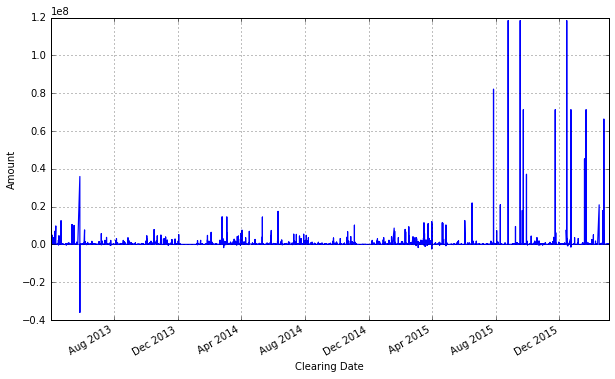

```python
df.sort_values('Clearing Date').plot(x = 'Clearing Date', y = 'Amount',legend=None,
    grid=True,lw=1.2, figsize=(10,6))
plt.ylabel('Amount')
```

which shows that expenditures boosted after August 2015.

*The most expensive payments were all devoted to the Transport for London*

```python
df.sort_values('Amount',ascending=False).drop_duplicates(subset='Amount').head(5)
```

|  | Amount | Clearing Date | Directorate | Expenditure Account Code Description | Service Expenditure Analysis | Vendor Name |
| --- | --- | --- | --- | --- | --- | --- |
| 5494 | 118379401.6 | 2015-09-17 | RESOURCES | FUNCTIONAL BODY GRANT PAYMENT | Highways and transport services | TRANSPORT FOR LONDON |
| 6394 | 82079402.0 | 2015-07-28 | RESOURCES | FUNCTIONAL BODY GRANT PAYMENT | Highways and transport services | TRANSPORT FOR LONDON |
| 843 | 71226538.0 | 2016-01-21 | RESOURCES | FUNCTIONAL BODY GRANT PAYMENT | Highways and transport services | TRANSPORT FOR LONDON |
| 0 | 66253087.0 | 2016-02-24 | RESOURCES | FUNCTIONAL BODY GRANT PAYMENT | Highways and transport services | TRANSPORT FOR LONDON |
| 844 | 45200000.0 | 2016-01-18 | RESOURCES | FUNCTIONAL BODY GRANT PAYMENT | Highways and transport services | TRANSPORT FOR LONDON |

*Sorted total payments grouped by `Expenditure Account Code Description` (top 5 rows only)* :

```python
grouped = df.groupby('Expenditure Account Code Description')
grouped.sum().sort_values('Amount',ascending=False).head(5)
```

| Expenditure Account Code Description | Amount |
| --- | --- |
| FUNCTIONAL BODY GRANT PAYMENT | 8.860160e+08 |
| GRANTS TO EXTERNAL ORGANISATIONS | 8.219761e+08 |
| HSG GRANTS TO REGISTERED PROVIDERS | 6.410579e+08 |
| HSG GRANTS TO LOCAL AUTHORITIES | 6.048305e+07 |
| CLAIM SETTLEMENTS | 5.064087e+07 |

*Sorted total payments grouped by `Vendor Name` (top 5 rows only)*

```python
grouped = df.groupby('Vendor Name')
grouped.sum().sort_values('Amount',ascending=False).head(5)
```

| Vendor Name | Amount |
| --- | --- |
| TRANSPORT FOR LONDON | 9.215039e+08 |
| LONDON BOROUGH OF LAMBETH | 1.110529e+08 |
| LONDON BOROUGH OF SOUTHWARK | 8.799278e+07 |
| LONDON AND QUADRANT HOUSING TRUST | 8.457841e+07 |
| LONDON BOROUGH OF LEWISHAM | 6.649843e+07 |

*Pie chart of total expenditure grouped by `Directorate` (only top 5 shown)*

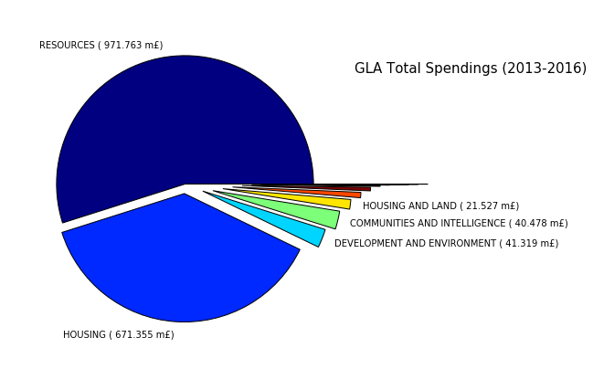

```python
# Filter out rows with missing 'Directorate' and group the result
grouped = df[~df['Directorate'].isnull()].groupby('Directorate')

total = grouped.sum().sort_values('Amount',ascending=False) # Sort by 'amount'

# Reformat the 'Amount' column
float_formatter = lambda x: "%.2f" % x
format_amount = (total.Amount.values/10**6)
format_amount = [ "{:0.3f}".format(x) for x in format_amount ]
labels = total.index.values + ' ( ' + format_amount + ' m' + u'\u00A3)'

# Show only first 5 labels
labels[5:] = ''

cmap = plt.cm.jet
colors = cmap(np.linspace(0., 2., len(total)))
explode = tuple(np.linspace(0,0.8,len(total)))

plt.figure(figsize=(7,7))
patches, texts = plt.pie(total['Amount'], radius=0.9, startangle=0,
                         colors=colors, explode=explode, labels=labels)
_ = [texts[i] for i in range(0,len(total))]

plt.title('GLA Total Spendings (2013-2016)', x=1.3,y=0.8, fontsize=15)
```

*Amount spent for each directorate grouped by `year`. Note the log scale on the x-axis*

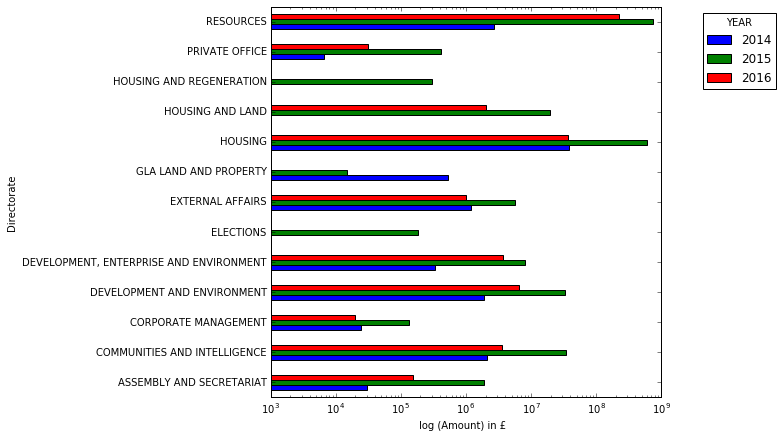

```python
df['year'] = map(lambda x: x.year, df['Clearing Date'])
grouped = df.groupby(['Directorate','year']).agg({'Amount':sum})
df2 = grouped.unstack()
df2.plot.barh(logx=True,figsize=(7, 7), stacked=False, legend=False)

labels = df2.columns.get_level_values(1).values
plt.legend(title='YEAR', loc=9, bbox_to_anchor=(1.2,1), labels=labels)

plt.xlabel(u'log (Amount) in \u00A3  ')
```

I do not know if `DEVELOPMENT and ENVIRONMENT` is the same as 'DEVELOPMENT, ENTERPRISE and ENVIRONMENT', or if 'HOUSING AND REGENERATION' is a different name for 'HOUSING AND LAND'. If so, their total 'Amount' should be summed together. While writing, we are only half way through 2016, which explains why the expenditure in 2016 is generally less than expenditure in 2015.

# Wrapping up

`BeautifulSoup` is a simple and powerful python library to extract information from web pages (`html` and `xml` files). I have shown how to use `BeautifulSoup` to extract `.csv` files from the Greater London Authority web page and read their content using `pandas`, which is by far the best library for data analysis with python. GLA spent almost 1 billion of pounds for Transport for London from April 2013 to March 2016, followed by housing services and boroughs. However, about 40% of GLA budget goes to housing-related services.